# Estandarización de Variables (Numéricas): Z-score

Miguel Angel Luque Fernández, PhD

26 de septiembre de 2025

[figure not shown]

# Estandarización de Variables (Numéricas): Z-score y Cálculo de Probabilidades y Percentiles

## 1. Introducción y Definición de Datos

Este documento ilustra el proceso de estandarización de una variable numérica (Talla) utilizando el **Z-score** y cómo se emplean los valores estandarizados para el cálculo de probabilidades y percentiles bajo el supuesto de una distribución normal. Definimos el vector de datos para la **Talla** (en cm):

```r
talla <- c(170, 165, 180, 175, 160, 185, 190, 178, 172, 168,
           182, 177, 169, 174, 181, 176, 183, 171, 167, 179)
```

## 2. Estadísticos Descriptivos y Visualización

Verificamos la media y la desviación estándar de la variable original.

```r
# Media
media_talla <- mean(talla); media_talla
```

```
## [1] 175.1
```

```r
# Desviación estándar
sd_talla <- sd(talla); sd_talla
```

```
## [1] 7.447359
```

### 2.1 Visualización de la Talla

Visualizamos la distribución de la Talla con un **Boxplot** y un **Histograma**, al que le superponemos la curva de densidad normal correspondiente.

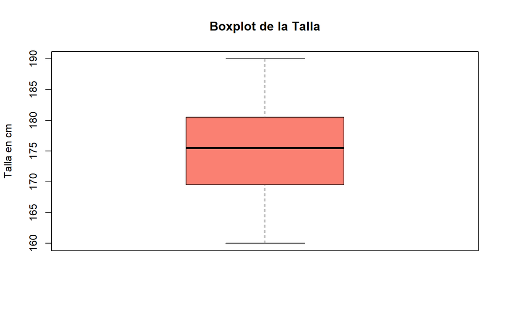

```r
# Boxplot
boxplot(talla, main = "Boxplot de la Talla",
        ylab = "Talla en cm", col = "salmon")
```

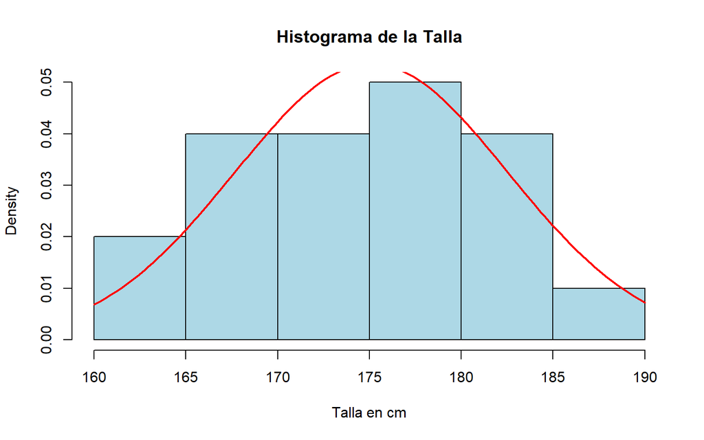

```r
# Histograma con línea de densidad normal
hist(talla, main = "Histograma de la Talla",
     xlab = "Talla en cm", breaks = 10, col = "lightblue", freq = FALSE)
curve(dnorm(x, mean = media_talla, sd = sd_talla),
      col = "red", lwd = 2, add = TRUE)
```

## 3. Estandarización de la Variable (Z-score)

Estandarizar una variable consiste en transformarla para que tenga una media de **0** y una desviación estándar de **1**.

### 3.1 Método Automático (`scale()`)

R provee la función `scale()` para realizar esta transformación automáticamente.

```r
ztalla_scale <- as.vector(scale(talla)) # Convierte a vector si es necesario
```

### 3.2 Método Manual (Creando una Función)

También se puede crear una función explícita para el cálculo del Z-score: $Z = (x - \mu) / \sigma$.

```r
# Creando función para estandarizar
std <- function(x) {
    return((x - mean(x)) / sd(x))
}
ztalla <- std(talla)

# Ajustar opciones para mostrar resultados sin notación científica
options(scipen = 999)
```

### 3.3 Verificación de la Estandarización

Una vez estandarizada, la nueva variable (`ztalla`) debe tener una media cercana a **0** y una desviación estándar de **1**.

```r
# Media de ztalla (debe ser aproximadamente 0)
mean(ztalla)
```

```
## [1] 0.0000000000000007566864
```

```r
# Desviación estándar de ztalla (debe ser aproximadamente 1)
sd(ztalla)
```

```
## [1] 1
```

## 4. Cálculo de Probabilidades

Usaremos la distribución normal estandarizada ($Z \sim N(0, 1)$) para calcular probabilidades.

### 4.1 Ejemplo: Probabilidad de medir más de 189.7 cm

Calculamos el Z-score correspondiente a una talla de 189.7 cm.

```r
talla_ejemplo <- 189.7
ztalla_ejemplo <- (talla_ejemplo - media_talla) / sd_talla; ztalla_ejemplo
```

```
## [1] 1.960426
```

La probabilidad de que una persona mida más de 189.7 cm se calcula como $P(\text{Talla} > 189.7)$. En las tablas de dos colas la probabilidad de la distribución normal estandarizada correspondiente a Z = 1.96 es aproximadamente 0.05, por lo que la probabilidad de medir más de 189.7 cm es aproximadamente 0.05/2 = 0.025 (2.5%).

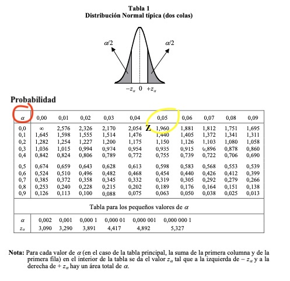

```r
# 1. P(Talla > 189.7)
prob1 <- round(1 - pnorm(talla_ejemplo, mean = media_talla, sd = sd_talla), 3); prob1
```

```
## [1] 0.025
```

```r
# 2. Alternativamente
prob2 <- round(pnorm(talla_ejemplo, mean = media_talla, sd = sd_talla, lower.tail=FALSE), 3); prob2
```

```
## [1] 0.025
```

```r
cat("La probabilidad de medir más de", talla_ejemplo, "cm es aproximadamente:", prob2, "\n")
```

```
## La probabilidad de medir más de 189.7 cm es aproximadamente: 0.025
```

### 4.2 Visualización de la Talla Estandarizada y la Probabilidad

Visualizamos la variable estandarizada (`ztalla`) y sombreamos el área de probabilidad 0.025 calculada (usaremos `ztalla_ejemplo` como `ztalla_189.7` en el código, asumiendo una ligera variación en los datos originales por motivos de visualización si fuese necesario).

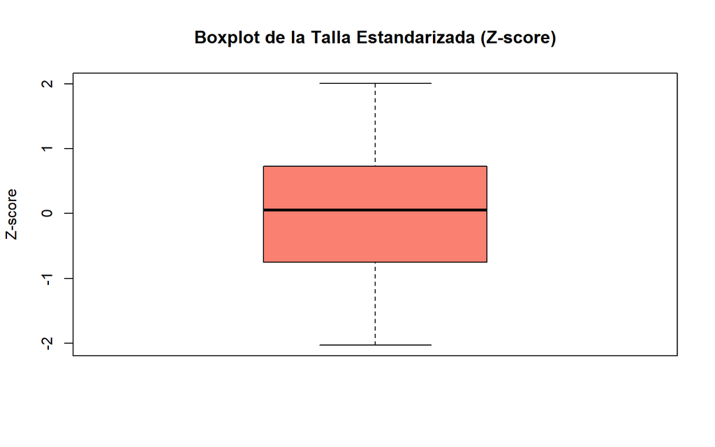

```r
# Boxplot de ztalla
boxplot(ztalla, main = "Boxplot de la Talla Estandarizada (Z-score)",
        ylab = "Z-score", col = "salmon")
```

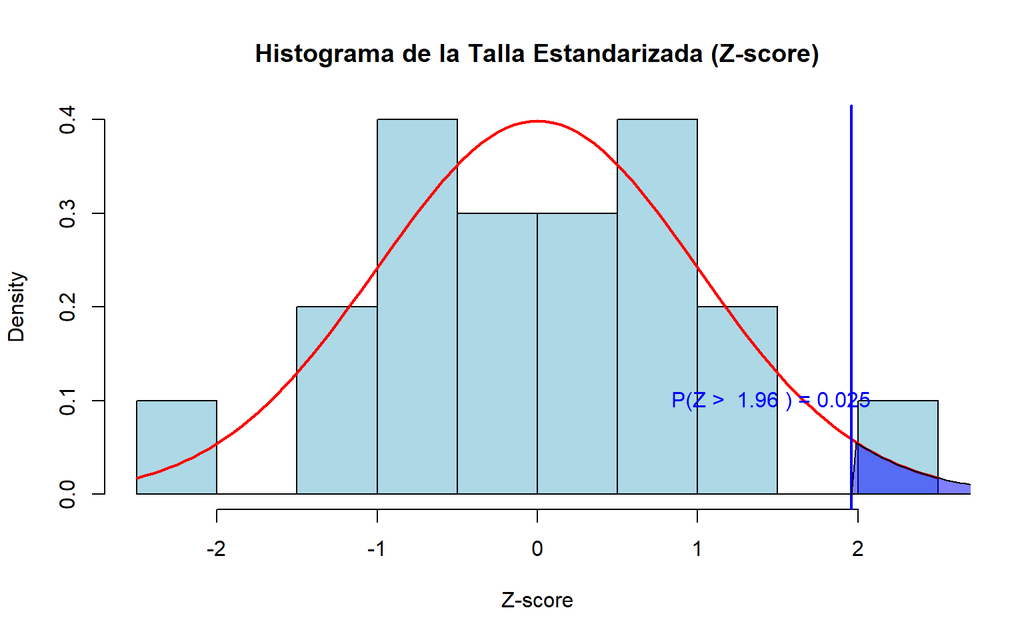

```r
# Histograma de ztalla
hist(ztalla, main = "Histograma de la Talla Estandarizada (Z-score)",
     xlab = "Z-score", breaks = 10, col = "lightblue", freq = FALSE)
# Curva de densidad normal (media=0, sd=1)
curve(dnorm(x, mean = 0, sd = 1), col = "red", lwd = 2, add = TRUE)

# Línea vertical en el Z-score de interés
abline(v = ztalla_ejemplo, col = "blue", lwd = 2)

# Sombrear el área bajo la curva a la derecha (Probabilidad de cola superior)
x <- seq(-4, 4, length = 200)
y <- dnorm(x, mean = 0, sd = 1)
polygon(c(ztalla_ejemplo, x[x >= ztalla_ejemplo], max(x)),
        c(0, y[x >= ztalla_ejemplo], 0), col = rgb(0, 0, 1, 0.5))

# Añadir texto con probabilidad
text(ztalla_ejemplo - 0.5, 0.1,
     paste("P(Z > ", round(ztalla_ejemplo, 2), ") =", prob2),
     col = "blue")
```

## 5. Cálculo de Percentiles (Valores Críticos)

Un zscore es un valor estandarizado que indica cuántas desviaciones estándar un dato está por encima o por debajo de la media. Su formula es:

$$Z = \frac{(X -
\mu)}{\sigma}$$
.

Por lo tanto, los percentiles se pueden calcular utilizando la propiedad del Z-score:

$$x = \mu + Z \sigma$$
.

El Z-score para el percentil 97.5% es $\approx 1.96$ y para el 2.5% es $\approx -1.96$. En R usamos la función **`qnorm`** en R se utiliza para encontrar el valor de la variable ($x$) o el Z-score ($z$) que corresponde a una probabilidad acumulada dada (percentil). Esto es fundamental para el cálculo de **Intervalos de Confianza** y lo veremos en los temas que vienen.

```r
qnorm(0.975)  # Z-score para el percentil 97.5%
```

```
## [1] 1.959964
```

```r
qnorm(0.025)  # Z-score para el percentil 2.5
```

```
## [1] -1.959964
```

### 5.1 Cálculo de los percentiles **97.5%** y **2.5%** con R

Calculamos los percentiles **97.5%** y **2.5%** de la **población** (los límites típicos de un intervalo de confianza del 95% que veremos con detalle en próximos temas).

```r
# Percentil 97.5% de la población (Límite superior)
q97.5 <- qnorm(0.975, mean = media_talla, sd = sd_talla); q97.5
```

```
## [1] 189.6966
```

```r
# Percentil 2.5% de la población (Límite inferior)
q2.5 <- qnorm(0.025, mean = media_talla, sd = sd_talla); q2.5
```

```
## [1] 160.5034
```

```r
cat("\nPercentil 97.5% (Talla):", round(q97.5, 2), "cm\n")
```

```
##
## Percentil 97.5% (Talla): 189.7 cm
```

```r
cat("Percentil 2.5% (Talla):", round(q2.5, 2), "cm\n")
```

```
## Percentil 2.5% (Talla): 160.5 cm
```

### 5.2 Alternativas de Cálculo

```r
# 1. Usando el Z-score (qnorm(p) con media=0, sd=1)
q_z_97.5 <- qnorm(0.975); q_z_97.5
```

```
## [1] 1.959964
```

```r
q_z_2.5 <- qnorm(0.025); q_z_2.5
```

```
## [1] -1.959964
```

```r
limite_superior <- media_talla + sd_talla * q_z_97.5; limite_superior
```

```
## [1] 189.6966
```

```r
limite_inferior <- media_talla + sd_talla * q_z_2.5; limite_inferior
```

```
## [1] 160.5034
```

```r
# 2. Usando el valor crítico 1.96 directamente
limite_superior_1.96 <- media_talla + sd_talla * 1.96; limite_superior_1.96
```

```
## [1] 189.6968
```

```r
limite_inferior_1.96 <- media_talla - sd_talla * 1.96; limite_inferior_1.96
```

```
## [1] 160.5032
```

Graficamente se vería así:

```
## [1] 189.6966
```

```
## [1] 160.5034
```

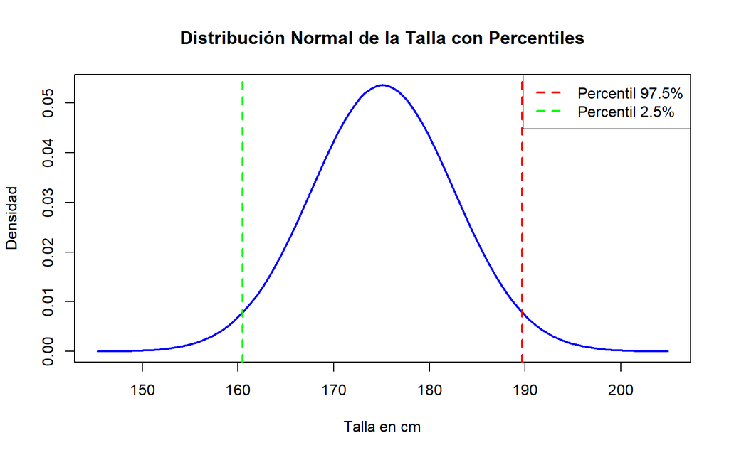